# Project: Investigate a Dataset (-TMDb Movie Data-)

- Introduction
- Data Wrangling
- Exploratory Data Analysis
- Conclusions

## Introduction

This data set contains information about 10,000 movies collected fromThe Movie Database (TMDb),including user ratings and revenue.

● Certain columns, like ‘cast’ and ‘genres’, contain multiple values separated by pipe (|) characters.

● There are some odd characters in the ‘cast’ column. Don’t worry about cleaning them. You can leave them as is.

● The final two columns ending with “_adj” show the budget and revenue of the associated movie in terms of 2010 dollars, accounting for inflation over time.

## Questions

### Research Question 1: (What are the five highest profit movies?)

### Research Question 2: (What are the five highest popular movies?)

### Research Question 3: (What are the five highest budget movies?)

### Research Question 4: (What are the five longest runtime movies?)

### Research Question 5: (What are the most five frequent genres?)

### Research Question 6: (Budget Over Years?)

### Research Question 7: (Runtime Over Years?)

### Research Question 8: (Popularity Over Years?)

```python
import pandas as pd
import numpy as np
import matplotlib.pyplot as plt
%matplotlib inline
import seaborn as sns; sns.set()
```

```python
# Do not truncate data in cells
pd.set_option('display.max_colwidth', None)

# Do not limit number of displayed columns
pd.set_option('display.max_columns', None)

# Display floats with 2 decimals
pd.set_option('display.float_format', '{:20,.2f}'.format)
```

# 1: Gathering data ;

### * Importing -TMDb Movie Data-

```python
# Load your data and print out a few lines. Perform operations to inspect data
#   types and look for instances of missing or possibly errant data.
df_movies = pd.read_csv('tmdb-movies.csv')
df_movies.sample(1)
```

|  | id | imdb_id | popularity | budget | revenue | original_title | cast | homepage | director | tagline | keywords | overview | runtime | genres | production_companies | release_date | vote_count | vote_average | release_year | budget_adj | revenue_adj |
| --- | --- | --- | --- | --- | --- | --- | --- | --- | --- | --- | --- | --- | --- | --- | --- | --- | --- | --- | --- | --- | --- |
| 5297 | 1968 | tt0119141 | 0.68 | 0 | 29481428 | Fools Rush In | Matthew Perry\|Salma Hayek\|Jon Tenney\|Siobhan Fallon\|Angelina Torres | NaN | Andy Tennant | What if finding the love of your life meant changing the life that you loved? | waitress\|culture clash\|romantic comedy\|pregnancy | Alex Whitman (Matthew Perry) is a designer from New York City who is sent to Las Vegas to supervise the construction of a nightclub that his firm has been hired to build. Alex is a straight-laced WASP… | 109 | Drama\|Comedy\|Romance | Columbia Pictures | 2/14/97 | 71 | 6.00 | 1997 | 0.00 | 40,049,350.15 |

# 2: Assessing Data ;

```python
df_movies.shape
```

```
(10866, 21)
```

```python
df_movies.head(5)
```

|  | id | imdb_id | popularity | budget | revenue | original_title | cast | homepage | director | tagline | keywords | overview | runtime | genres | production_companies | release_date | vote_count | vote_average | release_year | budget_adj | revenue_adj |
| --- | --- | --- | --- | --- | --- | --- | --- | --- | --- | --- | --- | --- | --- | --- | --- | --- | --- | --- | --- | --- | --- |
| 0 | 135397 | tt0369610 | 32.99 | 150000000 | 1513528810 | Jurassic World | Chris Pratt\|Bryce Dallas Howard\|Irrfan Khan\|Vincent D'Onofrio\|Nick Robinson | http://www.jurassicworld.com/ | Colin Trevorrow | The park is open. | monster\|dna\|tyrannosaurus rex\|velociraptor\|island | Twenty-two years after the events of Jurassic Park, Isla Nublar now features a fully functioning dinosaur theme park, Jurassic World, as originally envisioned by John Hammond. | 124 | Action\|Adventure\|Science Fiction\|Thriller | Universal Studios\|Amblin Entertainment\|Legendary Pictures\|Fuji Television Network\|Dentsu | 6/9/15 | 5562 | 6.50 | 2015 | 137,999,939.28 | 1,392,445,892.52 |
| 1 | 76341 | tt1392190 | 28.42 | 150000000 | 378436354 | Mad Max: Fury Road | Tom Hardy\|Charlize Theron\|Hugh Keays-Byrne\|Nicholas Hoult\|Josh Helman | http://www.madmaxmovie.com/ | George Miller | What a Lovely Day. | future\|chase\|post-apocalyptic\|dystopia\|australia | An apocalyptic story set in the furthest reaches of our planet, in a stark desert landscape where humanity is broken, and most everyone is crazed fighting for the necessities of life. Within this worl… | 120 | Action\|Adventure\|Science Fiction\|Thriller | Village Roadshow Pictures\|Kennedy Miller Productions | 5/13/15 | 6185 | 7.10 | 2015 | 137,999,939.28 | 348,161,292.49 |
| 2 | 262500 | tt2908446 | 13.11 | 110000000 | 295238201 | Insurgent | Shailene Woodley\|Theo James\|Kate Winslet\|Ansel Elgort\|Miles Teller | http://www.thedivergentseries.movie/#insurgent | Robert Schwentke | One Choice Can Destroy You | based on novel\|revolution\|dystopia\|sequel\|dystopic future | Beatrice Prior must confront her inner demons and continue her fight against a powerful alliance which threatens to tear her society apart. | 119 | Adventure\|Science Fiction\|Thriller | Summit Entertainment\|Mandeville Films\|Red Wagon Entertainment\|NeoReel | 3/18/15 | 2480 | 6.30 | 2015 | 101,199,955.47 | 271,619,025.41 |
| 3 | 140607 | tt2488496 | 11.17 | 200000000 | 2068178225 | Star Wars: The Force Awakens | Harrison Ford\|Mark Hamill\|Carrie Fisher\|Adam Driver\|Daisy Ridley | http://www.starwars.com/films/star-wars-episode-vii | J.J. Abrams | Every generation has a story. | android\|spaceship\|jedi\|space opera\|3d | Thirty years after defeating the Galactic Empire, Han Solo and his allies face a new threat from the evil Kylo Ren and his army of Stormtroopers. | 136 | Action\|Adventure\|Science Fiction\|Fantasy | Lucasfilm\|Truenorth Productions\|Bad Robot | 12/15/15 | 5292 | 7.50 | 2015 | 183,999,919.04 | 1,902,723,129.80 |
| 4 | 168259 | tt2820852 | 9.34 | 190000000 | 1506249360 | Furious 7 | Vin Diesel\|Paul Walker\|Jason Statham\|Michelle Rodriguez\|Dwayne Johnson | http://www.furious7.com/ | James Wan | Vengeance Hits Home | car race\|speed\|revenge\|suspense\|car | Deckard Shaw seeks revenge against Dominic Toretto and his family for his comatose brother. | 137 | Action\|Crime\|Thriller | Universal Pictures\|Original Film\|Media Rights Capital\|Dentsu\|One Race Films | 4/1/15 | 2947 | 7.30 | 2015 | 174,799,923.09 | 1,385,748,801.47 |

```python
df_movies.tail(5)
```

|  | id | imdb_id | popularity | budget | revenue | original_title | cast | homepage | director | tagline | keywords | overview | runtime | genres | production_companies | release_date | vote_count | vote_average | release_year | budget_adj | revenue_adj |
| --- | --- | --- | --- | --- | --- | --- | --- | --- | --- | --- | --- | --- | --- | --- | --- | --- | --- | --- | --- | --- | --- |
| 10861 | 21 | tt0060371 | 0.08 | 0 | 0 | The Endless Summer | Michael Hynson\|Robert August\|Lord 'Tally Ho' Blears\|Bruce Brown\|Chip Fitzwater | NaN | Bruce Brown | NaN | surfer\|surfboard\|surfing | The Endless Summer, by Bruce Brown, is one of the first and most influential surf movies of all times. The film documents American surfers Mike Hynson and Robert August as they travel the world during… | 95 | Documentary | Bruce Brown Films | 6/15/66 | 11 | 7.40 | 1966 | 0.00 | 0.00 |
| 10862 | 20379 | tt0060472 | 0.07 | 0 | 0 | Grand Prix | James Garner\|Eva Marie Saint\|Yves Montand\|ToshirÅ Mifune\|Brian Bedford | NaN | John Frankenheimer | Cinerama sweeps YOU into a drama of speed and spectacle! | car race\|racing\|formula 1 | Grand Prix driver Pete Aron is fired by his team after a crash at Monaco that injures his teammate, Scott Stoddard. While Stoddard struggles to recover, Aron begins to drive for another team, and star… | 176 | Action\|Adventure\|Drama | Cherokee Productions\|Joel Productions\|Douglas & Lewis Productions | 12/21/66 | 20 | 5.70 | 1966 | 0.00 | 0.00 |
| 10863 | 39768 | tt0060161 | 0.07 | 0 | 0 | Beregis Avtomobilya | Innokentiy Smoktunovskiy\|Oleg Efremov\|Georgi Zhzhyonov\|Olga Aroseva\|Lyubov Dobrzhanskaya | NaN | Eldar Ryazanov | NaN | car\|trolley\|stealing car | An insurance agent who moonlights as a carthief steals cars various crooks and never from the common people. He sells the stolen cars and gives the money to charity. His best friend, a cop, is assigne… | 94 | Mystery\|Comedy | Mosfilm | 1/1/66 | 11 | 6.50 | 1966 | 0.00 | 0.00 |
| 10864 | 21449 | tt0061177 | 0.06 | 0 | 0 | What's Up, Tiger Lily? | Tatsuya Mihashi\|Akiko Wakabayashi\|Mie Hama\|John Sebastian\|Tadao Nakamaru | NaN | Woody Allen | WOODY ALLEN STRIKES BACK! | spoof | In comic Woody Allen's film debut, he took the Japanese action film "International Secret Police: Key of Keys" and re-dubbed it, changing the plot to make it revolve around a secret egg salad recipe. | 80 | Action\|Comedy | Benedict Pictures Corp. | 11/2/66 | 22 | 5.40 | 1966 | 0.00 | 0.00 |
| 10865 | 22293 | tt0060666 | 0.04 | 19000 | 0 | Manos: The Hands of Fate | Harold P. Warren\|Tom Neyman\|John Reynolds\|Diane Mahree\|Stephanie Nielson | NaN | Harold P. Warren | It's Shocking! It's Beyond Your Imagination! | fire\|gun\|drive\|sacrifice\|flashlight | A family gets lost on the road and stumbles upon a hidden, underground, devil-worshiping cult led by the fearsome Master and his servant Torgo. | 74 | Horror | Norm-Iris | 11/15/66 | 15 | 1.50 | 1966 | 127,642.28 | 0.00 |

```python
df_movies.info()
```

```
<class 'pandas.core.frame.DataFrame'>
RangeIndex: 10866 entries, 0 to 10865
Data columns (total 21 columns):
 #   Column                Non-Null Count  Dtype
---  ------                --------------  -----
 0   id                    10866 non-null  int64
 1   imdb_id               10856 non-null  object
 2   popularity            10866 non-null  float64
 3   budget                10866 non-null  int64
 4   revenue               10866 non-null  int64
 5   original_title        10866 non-null  object
 6   cast                  10790 non-null  object
 7   homepage              2936 non-null   object
 8   director              10822 non-null  object
 9   tagline               8042 non-null   object
 10  keywords              9373 non-null   object
 11  overview              10862 non-null  object
 12  runtime               10866 non-null  int64
 13  genres                10843 non-null  object
 14  production_companies  9836 non-null   object
 15  release_date          10866 non-null  object
 16  vote_count            10866 non-null  int64
 17  vote_average          10866 non-null  float64
 18  release_year          10866 non-null  int64
 19  budget_adj            10866 non-null  float64
 20  revenue_adj           10866 non-null  float64
dtypes: float64(4), int64(6), object(11)
memory usage: 1.7+ MB
```

```python
df_movies.columns
```

```
Index(['id', 'imdb_id', 'popularity', 'budget', 'revenue', 'original_title',
       'cast', 'homepage', 'director', 'tagline', 'keywords', 'overview',
       'runtime', 'genres', 'production_companies', 'release_date',
       'vote_count', 'vote_average', 'release_year', 'budget_adj',
       'revenue_adj'],
      dtype='object')
```

```python
df_movies.count()
```

```
id                      10866
imdb_id                 10856
popularity              10866
budget                  10866
revenue                 10866
original_title          10866
cast                    10790
homepage                 2936
director                10822
tagline                  8042
keywords                 9373
overview                10862
runtime                 10866
genres                  10843
production_companies     9836
release_date            10866
vote_count              10866
vote_average            10866
release_year            10866
budget_adj              10866
revenue_adj             10866
dtype: int64
```

```python
df_movies.isna().sum()
```

```
id                         0
imdb_id                   10
popularity                 0
budget                     0
revenue                    0
original_title             0
cast                      76
homepage                7930
director                  44
tagline                 2824
keywords                1493
overview                   4
runtime                    0
genres                    23
production_companies    1030
release_date               0
vote_count                 0
vote_average               0
release_year               0
budget_adj                 0
revenue_adj                0
dtype: int64
```

```python
df_movies.duplicated().sum()
```

```
1
```

```python
df_movies.describe()
```

|  | id | popularity | budget | revenue | runtime | vote_count | vote_average | release_year | budget_adj | revenue_adj |
| --- | --- | --- | --- | --- | --- | --- | --- | --- | --- | --- |
| count | 10,866.00 | 10,866.00 | 10,866.00 | 10,866.00 | 10,866.00 | 10,866.00 | 10,866.00 | 10,866.00 | 10,866.00 | 10,866.00 |
| mean | 66,064.18 | 0.65 | 14,625,701.09 | 39,823,319.79 | 102.07 | 217.39 | 5.97 | 2,001.32 | 17,551,039.82 | 51,364,363.25 |
| std | 92,130.14 | 1.00 | 30,913,213.83 | 117,003,486.58 | 31.38 | 575.62 | 0.94 | 12.81 | 34,306,155.72 | 144,632,485.04 |
| min | 5.00 | 0.00 | 0.00 | 0.00 | 0.00 | 10.00 | 1.50 | 1,960.00 | 0.00 | 0.00 |
| 25% | 10,596.25 | 0.21 | 0.00 | 0.00 | 90.00 | 17.00 | 5.40 | 1,995.00 | 0.00 | 0.00 |
| 50% | 20,669.00 | 0.38 | 0.00 | 0.00 | 99.00 | 38.00 | 6.00 | 2,006.00 | 0.00 | 0.00 |
| 75% | 75,610.00 | 0.71 | 15,000,000.00 | 24,000,000.00 | 111.00 | 145.75 | 6.60 | 2,011.00 | 20,853,251.08 | 33,697,095.72 |
| max | 417,859.00 | 32.99 | 425,000,000.00 | 2,781,505,847.00 | 900.00 | 9,767.00 | 9.20 | 2,015.00 | 425,000,000.00 | 2,827,123,750.41 |

```python
df_movies.isnull().sum()
```

```
id                         0
imdb_id                   10
popularity                 0
budget                     0
revenue                    0
original_title             0
cast                      76
homepage                7930
director                  44
tagline                 2824
keywords                1493
overview                   4
runtime                    0
genres                    23
production_companies    1030
release_date               0
vote_count                 0
vote_average               0
release_year               0
budget_adj                 0
revenue_adj                0
dtype: int64
```

```python
df_movies['revenue'].value_counts()
```

```
0            6016
12000000       10
10000000        8
11000000        7
6000000         6
             ...
53676580        1
617000          1
13001257        1
504050219       1
20518905        1
Name: revenue, Length: 4702, dtype: int64
```

```python
#count zero values in budget data
df_movies[(df_movies['budget']==0)].shape[0]
```

```
5696
```

```python
#count zero values in revenue data
df_movies[(df_movies['revenue']==0)].shape[0]
```

```
6016
```

```python
#count zero values in runtime data
df_movies[(df_movies['runtime']==0)].shape[0]
```

```
31
```

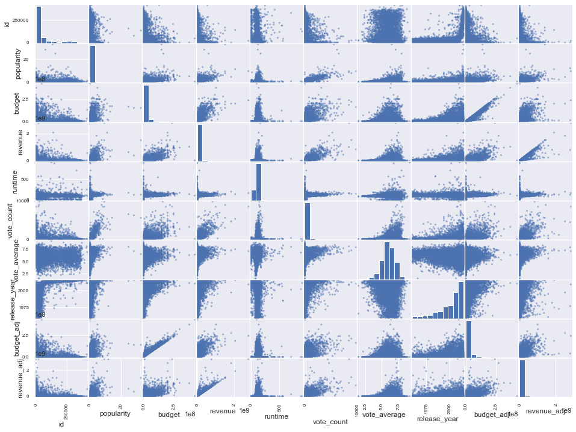

```python
pd.plotting.scatter_matrix(df_movies,figsize=[16,12]);
```

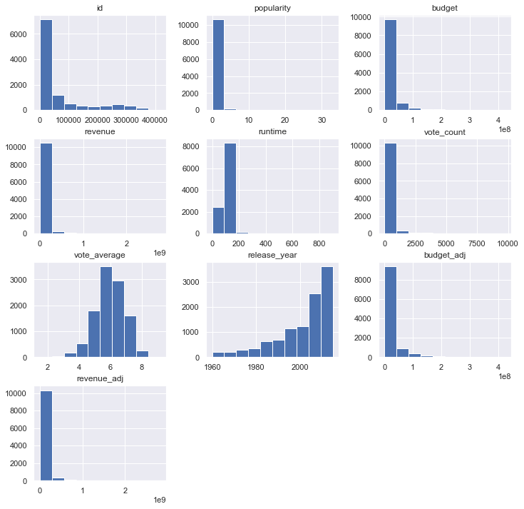

```python
df_movies.hist(figsize=(12,12));
```

## Summary of the assessment;

1- Drop unnecessary columns : 'imdb_id', 'homepage', 'tagline', 'overview', 'budget_adj', 'revenue_adj'.

2- Add a new column in the dataframe name 'Profit'

3- Drop duplicates.

4- rename column 'id' to 'tmdb_id'.

5- Replace zero values with null values in the budget, revenue and runtime column.

6- Changing Format Of Release Date Into Datetime Format.

# 4: Cleaning Data ;

## *Creating Dataframe copies*

```python
clean_df_movies = df_movies.copy()
clean_df_movies.head(2)
```

|  | id | imdb_id | popularity | budget | revenue | original_title | cast | homepage | director | tagline | keywords | overview | runtime | genres | production_companies | release_date | vote_count | vote_average | release_year | budget_adj | revenue_adj |
| --- | --- | --- | --- | --- | --- | --- | --- | --- | --- | --- | --- | --- | --- | --- | --- | --- | --- | --- | --- | --- | --- |
| 0 | 135397 | tt0369610 | 32.99 | 150000000 | 1513528810 | Jurassic World | Chris Pratt\|Bryce Dallas Howard\|Irrfan Khan\|Vincent D'Onofrio\|Nick Robinson | http://www.jurassicworld.com/ | Colin Trevorrow | The park is open. | monster\|dna\|tyrannosaurus rex\|velociraptor\|island | Twenty-two years after the events of Jurassic Park, Isla Nublar now features a fully functioning dinosaur theme park, Jurassic World, as originally envisioned by John Hammond. | 124 | Action\|Adventure\|Science Fiction\|Thriller | Universal Studios\|Amblin Entertainment\|Legendary Pictures\|Fuji Television Network\|Dentsu | 6/9/15 | 5562 | 6.50 | 2015 | 137,999,939.28 | 1,392,445,892.52 |
| 1 | 76341 | tt1392190 | 28.42 | 150000000 | 378436354 | Mad Max: Fury Road | Tom Hardy\|Charlize Theron\|Hugh Keays-Byrne\|Nicholas Hoult\|Josh Helman | http://www.madmaxmovie.com/ | George Miller | What a Lovely Day. | future\|chase\|post-apocalyptic\|dystopia\|australia | An apocalyptic story set in the furthest reaches of our planet, in a stark desert landscape where humanity is broken, and most everyone is crazed fighting for the necessities of life. Within this worl… | 120 | Action\|Adventure\|Science Fiction\|Thriller | Village Roadshow Pictures\|Kennedy Miller Productions | 5/13/15 | 6185 | 7.10 | 2015 | 137,999,939.28 | 348,161,292.49 |

### * Define

#### 1- Drop unnecessary columns : 'imdb_id', 'homepage', 'tagline', 'overview', 'budget_adj', 'revenue_adj'.

### ** Code

```python
colm = ['imdb_id', 'homepage', 'tagline', 'overview', 'budget_adj', 'revenue_adj']
clean_df_movies.drop(colm, axis=1, inplace=True)
```

### *** Test

```python
clean_df_movies.sample(2)
```

|  | id | popularity | budget | revenue | original_title | cast | director | keywords | runtime | genres | production_companies | release_date | vote_count | vote_average | release_year |
| --- | --- | --- | --- | --- | --- | --- | --- | --- | --- | --- | --- | --- | --- | --- | --- |
| 2087 | 51250 | 0.60 | 10000000 | 0 | Gun | 50 Cent\|Val Kilmer\|AnnaLynne McCord\|James Remar\|Hassan Johnson | Jessy Terrero | NaN | 81 | Action\|Thriller | Cheetah Vision\|Hannibal Pictures\|Emmett Furla Oasis Films (EFO Films) | 6/10/10 | 20 | 5.10 | 2010 |
| 4567 | 135281 | 0.48 | 0 | 0 | Camille redouble | Noémie Lvovsky\|Samir Guesmi\|Mathieu Amalric\|Judith Chemla\|India Hair | Noémie Lvovsky | woman director | 115 | Comedy\|Romance | Ciné@\|F Comme Film | 9/12/12 | 37 | 5.90 | 2012 |

### * Define

#### 2- Add a new column in the dataframe name 'Profit'

### ** Code

```python
clean_df_movies['Profit'] = clean_df_movies['revenue'] - clean_df_movies['budget']
```

### *** Test

```python
clean_df_movies.sample(2)
```

|  | id | popularity | budget | revenue | original_title | cast | director | keywords | runtime | genres | production_companies | release_date | vote_count | vote_average | release_year | Profit |
| --- | --- | --- | --- | --- | --- | --- | --- | --- | --- | --- | --- | --- | --- | --- | --- | --- |
| 5061 | 10943 | 0.48 | 0 | 0 | The Gathering | Christina Ricci\|Ioan Gruffudd\|Stephen Dillane\|Kerry Fox\|Robert Hardy | Brian Gilbert | amnesia\|excavation\|vision\|church\|archaeologist | 92 | Horror\|Thriller | Granada Film Productions\|Isle of Man Film\|Isle of Man Film Commission\|Samuelson Productions | 2/23/03 | 14 | 5.00 | 2003 | 0 |
| 8962 | 27475 | 0.06 | 0 | 0 | The Slumber Party Massacre | Michelle Michaels\|Robin Stille\|Michael Villella\|Debra Deliso\|Andree Honore | Amy Holden Jones | slasher\|woman director | 77 | Horror\|Comedy | Santa Fe Productions (I) | 11/12/82 | 17 | 6.00 | 1982 | 0 |

### * Define

#### 3- Drop duplicates.

### ** Code

```python
clean_df_movies.drop_duplicates(inplace=True)
```

### *** Test

```python
clean_df_movies.duplicated().sum()
```

```
0
```

### * Define

#### 4- rename column 'id' to 'tmdb_id'.

### ** Code

```python
clean_df_movies= clean_df_movies.rename(columns={'id':'tmdb_id'})
```

### *** Test

```python
clean_df_movies.sample(2)
```

|  | tmdb_id | popularity | budget | revenue | original_title | cast | director | keywords | runtime | genres | production_companies | release_date | vote_count | vote_average | release_year | Profit |
| --- | --- | --- | --- | --- | --- | --- | --- | --- | --- | --- | --- | --- | --- | --- | --- | --- |
| 2345 | 38883 | 0.13 | 0 | 0 | Protéger et servir | Kad Merad\|Clovis Cornillac\|Carole Bouquet\|François Damiens\|Elsa Kikoïne | Eric Lavaine | NaN | 90 | Comedy | M6 Films\|Same Player\|Pathé\|Scope Pictures\|Weber Investissements | 1/22/10 | 11 | 5.00 | 2010 | 0 |
| 3321 | 19197 | 0.09 | 170000 | 0 | Mum & Dad | Perry Benson\|Dido Miles\|Olga Fedori\|Ainsley Howard\|Toby Alexander | Steven Sheil | airport\|murder\|torture | 84 | Horror\|Thriller | EM Media\|Film London\|2am Films | 8/22/08 | 23 | 6.30 | 2008 | -170000 |

### * Define

#### 5- Replace zero values with null values in the budget, revenue and runtime column.

### ** Code

```python
clean_df_movies['budget'] = clean_df_movies['budget'].replace(0,np.NaN)
clean_df_movies['revenue'] = clean_df_movies['revenue'].replace(0,np.NaN)
clean_df_movies['runtime'] = clean_df_movies['runtime'].replace(0,np.NaN)
```

### *** Test

```python
clean_df_movies.info()
```

```
<class 'pandas.core.frame.DataFrame'>
Int64Index: 10865 entries, 0 to 10865
Data columns (total 16 columns):
 #   Column                Non-Null Count  Dtype
---  ------                --------------  -----
 0   tmdb_id               10865 non-null  int64
 1   popularity            10865 non-null  float64
 2   budget                5169 non-null   float64
 3   revenue               4849 non-null   float64
 4   original_title        10865 non-null  object
 5   cast                  10789 non-null  object
 6   director              10821 non-null  object
 7   keywords              9372 non-null   object
 8   runtime               10834 non-null  float64
 9   genres                10842 non-null  object
 10  production_companies  9835 non-null   object
 11  release_date          10865 non-null  object
 12  vote_count            10865 non-null  int64
 13  vote_average          10865 non-null  float64
 14  release_year          10865 non-null  int64
 15  Profit                10865 non-null  int64
dtypes: float64(5), int64(4), object(7)
memory usage: 1.4+ MB
```

### * Define

#### 6- Changing Format Of Release Date Into Datetime Format.

### ** Code

```python
clean_df_movies['release_date'] = pd.to_datetime(clean_df_movies['release_date'])
```

### *** Test

```python
clean_df_movies['release_date'].head()
```

```
0   2015-06-09
1   2015-05-13
2   2015-03-18
3   2015-12-15
4   2015-04-01
Name: release_date, dtype: datetime64[ns]
```

## Exploratory Data Analysis

### Research Question 1: (What are the five highest profit movies?)

```python
#Create separate data frame with ["Profit", "original_title"]
df_profit= clean_df_movies[["Profit", "original_title"]]
df_profit_2= pd.DataFrame(df_profit)
```

```python
#The five highest "profit" movies
df_profit_3= df_profit_2.nlargest(5, "Profit")
df_profit_3
```

|  | Profit | original_title |
| --- | --- | --- |
| 1386 | 2544505847 | Avatar |
| 3 | 1868178225 | Star Wars: The Force Awakens |
| 5231 | 1645034188 | Titanic |
| 0 | 1363528810 | Jurassic World |
| 4 | 1316249360 | Furious 7 |

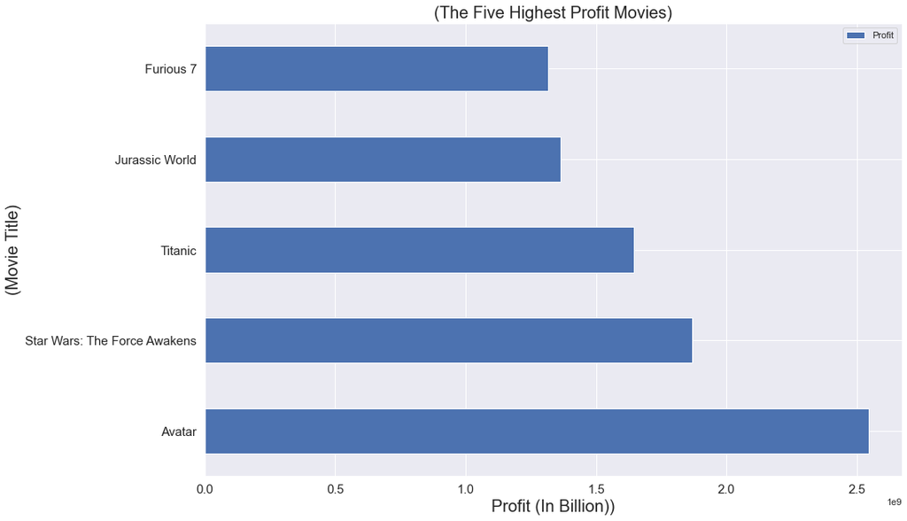

```python
df_profit_3.plot(kind='barh',x="original_title",y="Profit",figsize=(15,10))
#setup the title and labels of the figure.
plt.xlabel("Profit (In Billion))",fontsize = 20)
plt.ylabel("(Movie Title)",fontsize = 20)
plt.title("(The Five Highest Profit Movies)",fontsize = 20)
plt.xticks(fontsize = 15)
plt.yticks(fontsize = 15);
```

### - Conclusions;

##### - The five highest "Profit" movies ( Avatar -Star Wars: The Force Awakens - Titanic - Jurassic World - Furious 7 )

### Research Question 2: (What are the five highest popular movies?)

```python
#Create separate data frame with ["popularity", "original_title"]
df_pop= clean_df_movies[["popularity", "original_title"]]
df_pop_2= pd.DataFrame(df_pop)
```

```python
#The five highest "popularity" movies
df_pop_3= df_pop_2.nlargest(5, "popularity")
df_pop_3
```

|  | popularity | original_title |
| --- | --- | --- |
| 0 | 32.99 | Jurassic World |
| 1 | 28.42 | Mad Max: Fury Road |
| 629 | 24.95 | Interstellar |
| 630 | 14.31 | Guardians of the Galaxy |
| 2 | 13.11 | Insurgent |

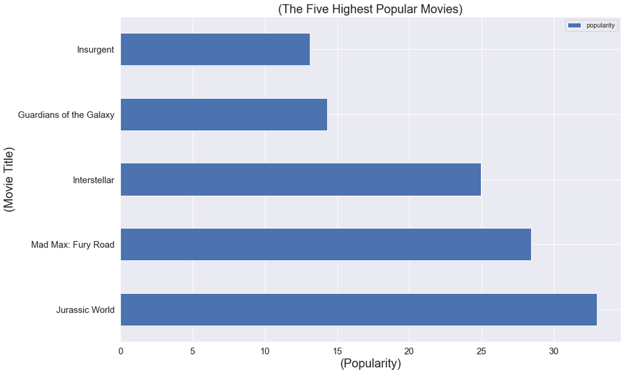

```python
df_pop_3.plot(kind='barh',x="original_title",y="popularity",figsize=(15,10))
#setup the title and labels of the figure.
plt.xlabel("(Popularity)",fontsize = 20)
plt.ylabel("(Movie Title)",fontsize = 20)
plt.title("(The Five Highest Popular Movies)",fontsize = 20)
plt.xticks(fontsize = 15)
plt.yticks(fontsize = 15);
```

### - Conclusions;

##### - The five highest "popularity" movies ( Jurassic World - Mad Max: Fury Road - Interstellar - Guardians of the Galaxy - Insurgent )

#### Research Question 3: (What are the five highest budget movies?)

```python
#Create separate data frame with ["budget", "original_title"]
df_budg= clean_df_movies[["budget","original_title"]]
df_budg_2= pd.DataFrame(df_budg)
```

```python
#The five highest "budget" movies
df_budg_3= df_budg_2.nlargest(5, "budget")
df_budg_3
```

|  | budget | original_title |
| --- | --- | --- |
| 2244 | 425,000,000.00 | The Warrior's Way |
| 3375 | 380,000,000.00 | Pirates of the Caribbean: On Stranger Tides |
| 7387 | 300,000,000.00 | Pirates of the Caribbean: At World's End |
| 14 | 280,000,000.00 | Avengers: Age of Ultron |
| 6570 | 270,000,000.00 | Superman Returns |

[figure not shown]

```python
df_budg_3.plot(kind='barh',x="original_title",y="budget",figsize=(15,10))
#setup the title and labels of the figure.
plt.xlabel("(Budget (In Million))",fontsize = 20)
plt.ylabel("(Movie Title)",fontsize = 20)
plt.title("(The Five Highest Popular Movies)",fontsize = 20)
plt.xticks(fontsize = 15)
plt.yticks(fontsize = 15);
```

### - Conclusions;

#### - The five highst "budget" movies ( The Warrior's Way - Pirates of the Caribbean: On Stranger Tides - Pirates of the Caribbean: At World's End - Avengers: Age of Ultron - Superman Returns )

### Research Question 4: (What are the five longest runtime movies?)

```python
#Create separate data frame with ["runtime", "original_title"]
df_time= clean_df_movies[["runtime","original_title"]]
df_time_2= pd.DataFrame(df_time)
```

```python
#The five highest "runtime" movies
df_time_3= df_time_2.nlargest(5, "runtime")
df_time_3
```

|  | runtime | original_title |
| --- | --- | --- |
| 3894 | 900.00 | The Story of Film: An Odyssey |
| 4041 | 877.00 | Taken |
| 2722 | 705.00 | Band of Brothers |
| 6176 | 566.00 | Shoah |
| 6181 | 561.00 | North and South, Book I |

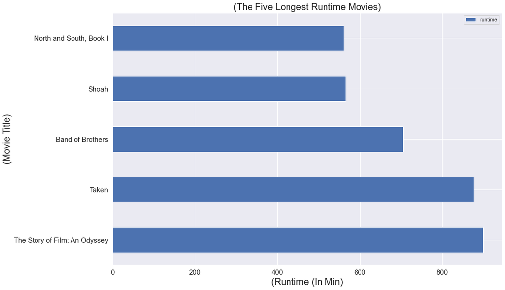

```python
df_time_3.plot(kind='barh',x="original_title",y="runtime",figsize=(15,10))
#setup the title and labels of the figure.
plt.xlabel("(Runtime (In Min)",fontsize = 20)
plt.ylabel("(Movie Title)",fontsize = 20)
plt.title("(The Five Longest Runtime Movies)",fontsize = 20)
plt.xticks(fontsize = 15)
plt.yticks(fontsize = 15);
```

### - Conclusions;

##### - The five longest "runtime" movies ( The Story of Film: An Odyssey - Taken - Band of Brothers - Shoah - North and South, Book I )

### Research Question 5: (What are the most five frequent genres?)

```python
data_genres = clean_df_movies['genres'].str.cat(sep = '|')
data_series = pd.Series(data_genres.split('|'))
genres_most_5 = data_series.value_counts(ascending=False)
genres_most_5
```

```
Drama              4760
Comedy             3793
Thriller           2907
Action             2384
Romance            1712
Horror             1637
Adventure          1471
Crime              1354
Family             1231
Science Fiction    1229
Fantasy             916
Mystery             810
Animation           699
Documentary         520
Music               408
History             334
War                 270
Foreign             188
TV Movie            167
Western             165
dtype: int64
```

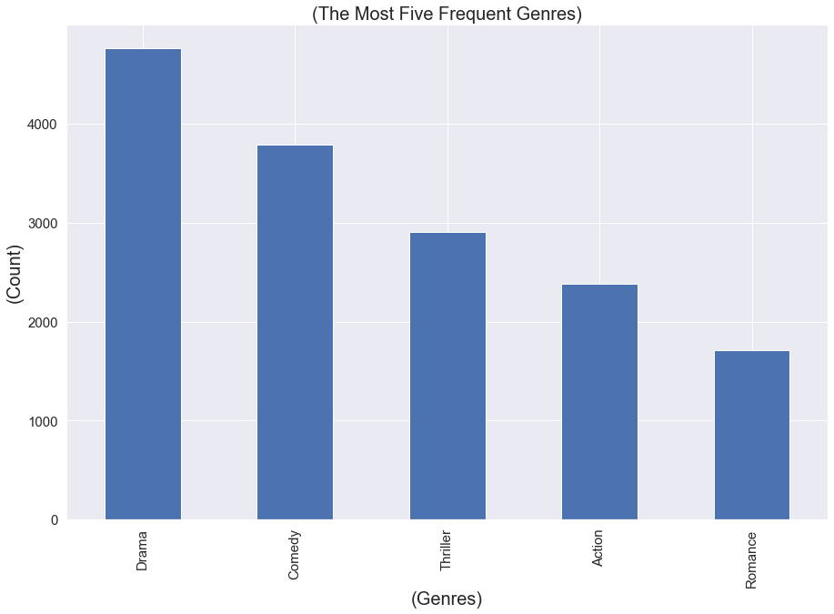

```python
genres_most_5[:5].plot.bar(figsize=(15,10))
#setup the title and labels of the figure.
plt.title('(The Most Five Frequent Genres)',fontsize=20)
plt.xlabel("(Genres)",fontsize = 20)
plt.ylabel("(Count)",fontsize = 20)
plt.xticks(fontsize = 15)
plt.yticks(fontsize = 15);
```

### - Conclusions;

#### - Drama has the most frequent Gener over years ( Drama - Comedy - Thriller - Action - Romance )

### Research Question 6: (Budget Over Years?)

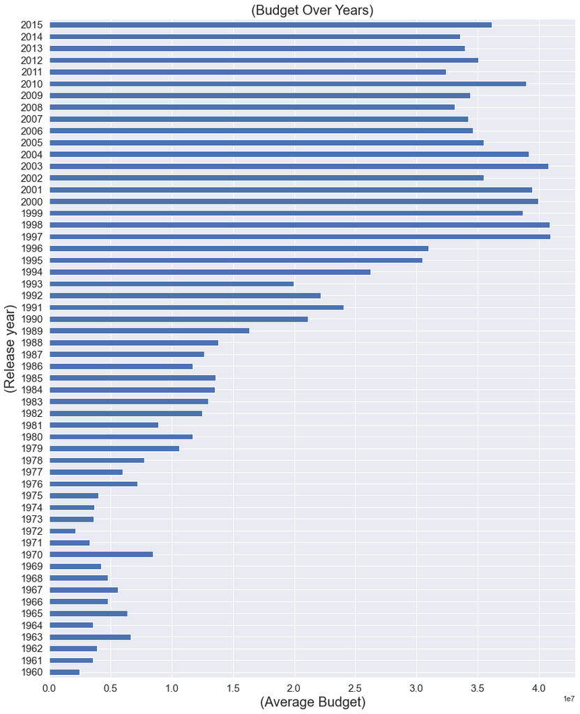

```python
clean_df_movies.groupby('release_year')['budget'].mean().plot.barh(figsize=(14,18))
#setup the title and labels of the figure.
plt.title('(Budget Over Years)',fontsize = 20)
plt.xlabel("(Average Budget)",fontsize = 20)
plt.ylabel("(Release year)",fontsize = 20)
plt.xticks(fontsize = 15)
plt.yticks(fontsize = 15);
```

### - Conclusions;

#### - AS we see in the plot the increase in the production budget over the years, and this makes us assume another question that needs separate study.

#### Is the movie industry making high profits?

### Research Question 7: (Runtime Over Years?)

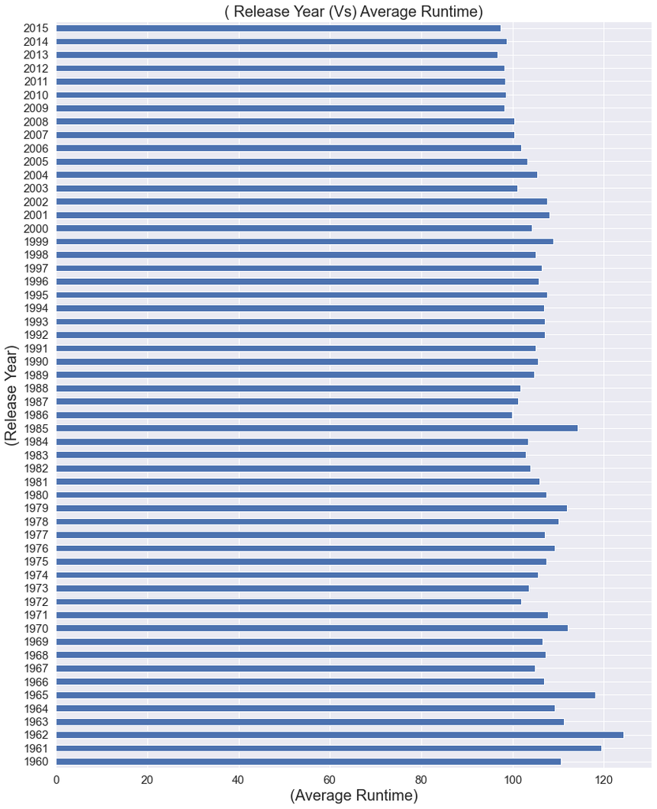

```python
clean_df_movies.groupby('release_year')['runtime'].mean().plot.barh(figsize=(14,18))
#setup the title and labels of the figure.
plt.title('( Release Year (Vs) Average Runtime)',fontsize = 20)
plt.xlabel("(Average Runtime)",fontsize = 20)
plt.ylabel("(Release Year)",fontsize = 20)
plt.xticks(fontsize = 15)
plt.yticks(fontsize = 15);
```

### - Conclusions;

#### - AS we see in the plot the decrease in the runtime of the films over the years and this makes us assume another question that needs separate study.

#### Is there a relationship between increasing the production of films annually and the runtime period ?

### Research Question 8: (Popularity Over Years?)

[figure not shown]

```python
clean_df_movies.groupby('release_year')['popularity'].mean().plot.barh(figsize=(14,18))
#setup the title and labels of the figure.
plt.title('(Release Year (Vs) Average popularity)',fontsize = 20)
plt.xlabel("(Release Year)",fontsize = 20)
plt.ylabel("(Average popularity)",fontsize = 20)
plt.xticks(fontsize = 15)
plt.yticks(fontsize = 15);
```

### - Conclusions;

#### - AS we see in the plot The popularity of movies increased over time and this makes us assume another question that needs separate study.

#### Is there a lack of information about old films?

## Conclusions

#### 4- The five longest "runtime" movies ( The Story of Film: An Odyssey - Taken - Band of Brothers - Shoah - North and South, Book I )

#### 5- Drama has the most frequent Gener over years ( Drama - Comedy - Thriller - Action - Romance )

#### 6- AS we see in the plot the increase in the production budget over the years, and this makes us assume another question that needs separate study.

#### Is the movie industry making high profits?

#### 7- AS we see in the plot the decrease in the runtime of the films over the years and this makes us assume another question that needs separate study.

#### Is there a relationship between increasing the production of films annually and the runtime period ?

#### 8- AS we see in the plot The popularity of movies increased over time and this makes us assume another question that needs separate study.

#### Is there a lack of information about old films?

### Limitations;

#### - I found missing values in many columns, and it's take too much time to cleaning them, As we'll see in dataframe 'df_movies.info()'

#### - I found some difficulty to dealing with the geners column until I used split method in dataframe '(data_series):'

```python
df_movies.info()
```

```
<class 'pandas.core.frame.DataFrame'>
RangeIndex: 10866 entries, 0 to 10865
Data columns (total 21 columns):
 #   Column                Non-Null Count  Dtype
---  ------                --------------  -----
 0   id                    10866 non-null  int64
 1   imdb_id               10856 non-null  object
 2   popularity            10866 non-null  float64
 3   budget                10866 non-null  int64
 4   revenue               10866 non-null  int64
 5   original_title        10866 non-null  object
 6   cast                  10790 non-null  object
 7   homepage              2936 non-null   object
 8   director              10822 non-null  object
 9   tagline               8042 non-null   object
 10  keywords              9373 non-null   object
 11  overview              10862 non-null  object
 12  runtime               10866 non-null  int64
 13  genres                10843 non-null  object
 14  production_companies  9836 non-null   object
 15  release_date          10866 non-null  object
 16  vote_count            10866 non-null  int64
 17  vote_average          10866 non-null  float64
 18  release_year          10866 non-null  int64
 19  budget_adj            10866 non-null  float64
 20  revenue_adj           10866 non-null  float64
dtypes: float64(4), int64(6), object(11)
memory usage: 1.7+ MB
```

```python
from subprocess import call
call(['python', '-m', 'nbconvert', 'Investigate_a_Dataset.ipynb'])
```

```
4294967295
```